# basic generalized linear models

Ben Bolker

Licensed under the [Creative Commons attribution-noncommercial license](http://creativecommons.org/licenses/by-nc/3.0/). Please share & remix noncommercially, mentioning its origin.

```r
library(ggplot2); theme_set(theme_bw())
library(ggExtra)
library(cowplot)
library(dotwhisker)
```

## Linear models

- foundation for (G)LM(M)s, other complex models
- flexible, robust, computationally efficient, standard
- includes (multiple) regression, ANOVA, ANCOVA, …
- natural ways to express dependence, interactions

## Linear models: assumptions

- response variables:
  - Gaussian (normally distributed)
  - independent
  - *conditionally* homoscedastic (equal variance)
  - univariate
- predictor variables
  - numeric or categorical (nominal)

## Linear models: math

$$z = a + bx + cy + \epsilon$$
or (more predictor variables)
$$y = \beta_0 + \beta_1 x_1 + \beta_2 x_2 + \ldots + \epsilon$$
or (more flexible distribution syntax)
$$y \sim \textrm{Normal}(\beta_0 + \beta_1 x_1 + \beta_2 x_2 + \ldots, \sigma^2)$$
or (more complex sets of predictors)
$$\begin{split}
\boldsymbol{\mu} & = \mathbf{X} \mathbf{\beta} \\
y_i & \sim \textrm{Normal}(\mu_i,\sigma^2)
\end{split}$$

## what does “linear” mean?

- $y$ is a linear function of the *parameters*  
  ($\partial^2 y/\partial^2 \beta_i = 0$)
- e.g. polynomials: $y = a + bx + cx^2 + dx^3$
- or sinusoids: $y = a \sin(x) + b \cos(x)$
- but **not**: power-law ($ax^b$), exponential ($a \exp(-bx)$)

## marginal vs. conditional distributions

- common mistake: worry about the overall distribution of the response,  
  rather than the *conditional* distribution (i.e., residuals)
- if only categorical predictors, can mean-correct each group, then look at residuals
- otherwise have to fit the model first!

## example

MPG vs displacement for cars

```r
cars_lm <- lm(log10(mpg)~log10(disp),mtcars)
```

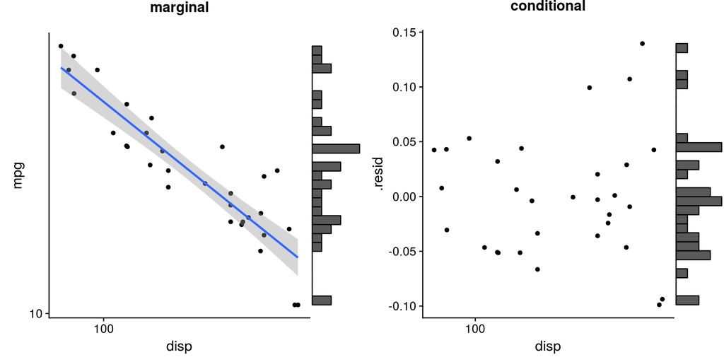

(We’ll come back to how to judge this later)

## categorical predictors

- how do categorical predictors fit into this scheme?
- *dummy variables*: convert to 0/1 values
- R does this automatically with formula syntax
- e.g. for two levels:

```r
dd <- data.frame(flavour=rep(c("chocolate","vanilla"),c(2,3)))
print(dd)
```

```
##     flavour
## 1 chocolate
## 2 chocolate
## 3   vanilla
## 4   vanilla
## 5   vanilla
```

```r
model.matrix(~flavour,dd)
```

```
##   (Intercept) flavourvanilla
## 1           1              0
## 2           1              0
## 3           1              1
## 4           1              1
## 5           1              1
## attr(,"assign")
## [1] 0 1
## attr(,"contrasts")
## attr(,"contrasts")$flavour
## [1] "contr.treatment"
```

- first alphabetical level (`chocolate`) used as default (use `relevel()` or `factor(...,levels=...)` to change default)
- *ordered factors* are handled differently

## R formulas

- Wilkinson and Rogers (1973)
- `response ~ predictor1 + predictor2 + ...`
- numeric variables used “as is”
- categorical variables (factors) converted to dummy variables
- intercept added automatically (`1+ ...`)
- interaction: `:` *multiplies* relevant columns
- `a*b`: main effect plus interactions
- `model.matrix(formula, data)`

## Formulas, continued

- `y~f`: 1-way ANOVA
- `y~f+g`: 2-way ANOVA (additive)
- `y~f*g`: 2-way ANOVA (with interaction)
- `y~x`: univariate regression
- `y~f+x`: ANCOVA (parallel slopes)
- `y~f*x`: ANCOVA (with interaction, non-parallel slopes)
- `y~x1+x2`: multivariate regression (additive)
- `y~x1*x2`: multiv. regression with interaction

If confused, (1) try to write out the equation; (2) `model.matrix()`

## Contrasts

too many ways to change contrasts (globally via `options()`; as attribute of factor; `contrasts` argument in `lm()`)

## Example 1 (treatment contrasts)

Data on ant colonies from Gotelli and Ellison (2004):

```r
ants <- data.frame(
    place=rep(c("field","forest"),c(6,4)),
    colonies=c(12, 9, 12, 10,
               9, 6, 4, 6, 7, 10))
aggregate(colonies~place,data=ants,FUN=mean)
```

```
##    place colonies
## 1  field 9.666667
## 2 forest 6.750000
```

```r
pr <- function(m) printCoefmat(coef(summary(m)),digits=3,signif.stars=FALSE)
pr(lm1 <- lm(colonies~place,data=ants))
```

```
##             Estimate Std. Error t value Pr(>|t|)
## (Intercept)    9.667      0.958   10.09    8e-06
## placeforest   -2.917      1.515   -1.92     0.09
```

## Ants: sum-to-zero contrasts

```r
pr(lm2 <- update(lm1, contrasts=list(place=contr.sum)))
```

```
##             Estimate Std. Error t value Pr(>|t|)
## (Intercept)    8.208      0.758   10.83  4.7e-06
## place1         1.458      0.758    1.92     0.09
```

```r
data(lizards,package="brglm")
```

## Interactions: example

- Bear road-crossing
- Predictor variables: sex (categorical: M/F), road type (categorical: major/minor), road length (continuous)
- **Two-way interactions**
  - sex $\times$ road length: “are females more sensitive to amount of road than males?”
  - sex $\times$ road type: “do females prefer major over minor roads more than males?”
  - road type $\times$ road length: “does amount of road affect crossings differently for different road types?”
- **Three-way interaction**: does the difference of the effect of road length between road types differ between sexes?

## Centering (Schielzeth 2010)

- in interaction models, interpretation of main effects **depends on the center-point of the predictors**
- *centering* makes main effects much more interpretable
  - numeric predictors (subtracting the mean by default; other choices could be sensible)
  - categorical predictors: sum-to-zero (weighted or unweighted)
- e.g. if Gregorian year is a predictor, the intercept is at year 0 (!)
- also improves model stability, decorrelates coefficients

## Scaling (Schielzeth 2010)

- scaling parameters improves interpretability
- standard deviation scaling:  
  parameter magnitudes = importance

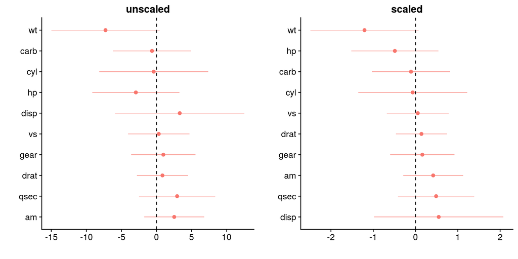

```r
mtcars_big <- lm(mpg~.,data=mtcars)
mtcars_big_sc <- lm(mpg~.,data=as.data.frame(scale(mtcars)))
dwfun <- function(.,title) { dwplot(.,order_vars=names(sort(coef(.))))+
                                 geom_vline(xintercept=0,linetype=2)+
                                 ggtitle(title) }
plot_grid(dwfun(mtcars_big,"unscaled"),dwfun(mtcars_big_sc,"scaled"))
```

## LM diagnostics

- fitted vs. residual: pattern in mean? (linearity)
- scale-location: pattern in variance? (homoscedasticity)
- Q-Q plot: Normality of **residuals**
- leverage/Cook’s distance: influential points?
- independence is often hard to test
- Normality is the **least important** of these assumptions

## LM diagnostics

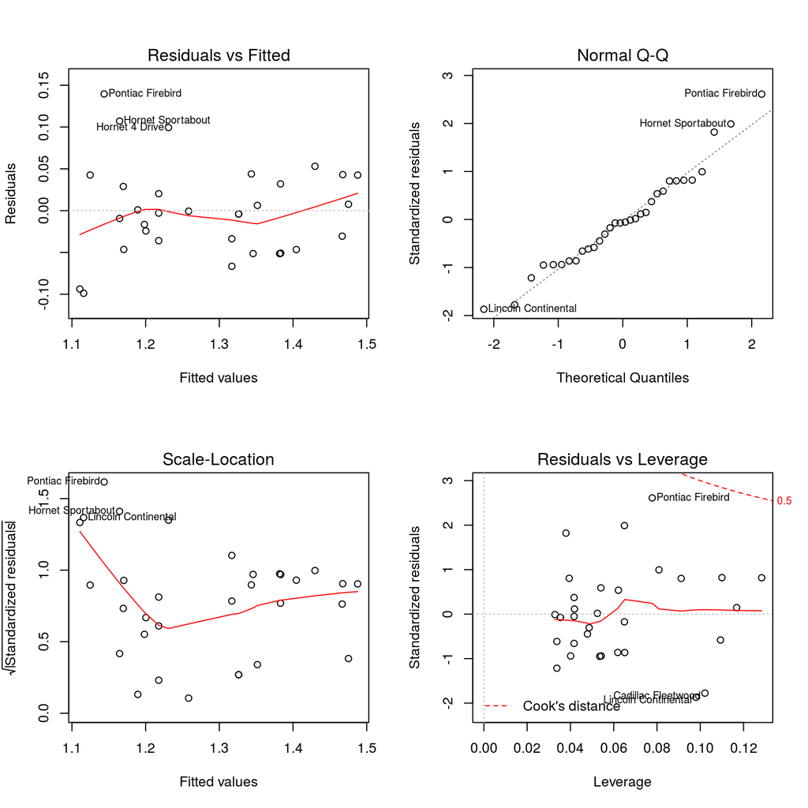

```r
par(mfrow=c(2,2))
plot(cars_lm)
```

- problems are not independent
- deal with problems in order (location > scale > outliers > distribution)
- smooth lines help interpretation
- highlighted points are 3 most extreme (`id.n` argument)

## a bad model (Tiwari et al. 2006)

- this is based on a GLM, but the ideas are the same

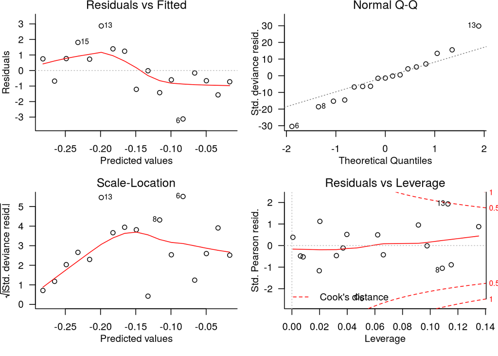

## original data/fit …

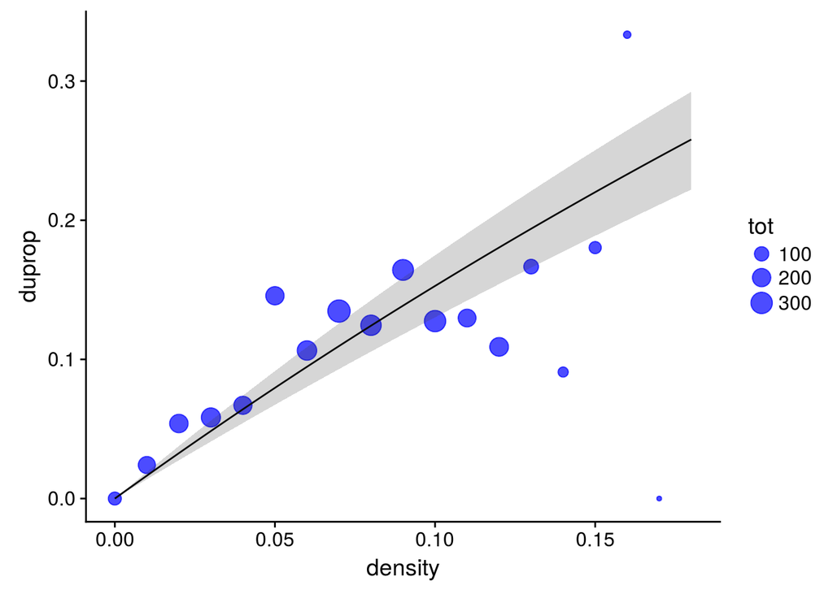

## Diagnostics

- statisticians: “don’t use p-values to evaluate LM assumptions”
- everyone else: “so what should I do?”
- statisticians: “look at pictures”
- everyone else: “how do I decide whether to worry?”
- statisticians: “…”

## testing hypotheses and interpreting results

- parameter-by-parameter: `summary()` ($t$ test)
- multi-parameter comparisons: `anova()`, `car::Anova()` ($F$ test)
- order matters
- interactions/main effects matter

# From LM to GLM

## Why GLMs?

- assumptions of LMs do break down sometimes
- count data: discrete, non-negative
- proportion data: discrete counts, $0 \le x \le N$
- hard to transform to Normal
- linear model doesn’t make sense

[figure not shown]

## GLMs in action

- vast majority of GLMs
  - *logistic regression* (binary/Bernoulli data)
  - *Poisson regression* (count data)
- lots of GLM theory carries over from LMs
  - formulas
  - parameter interpretation (partly)
  - diagnostics (partly)

## Most GLMs are logistic

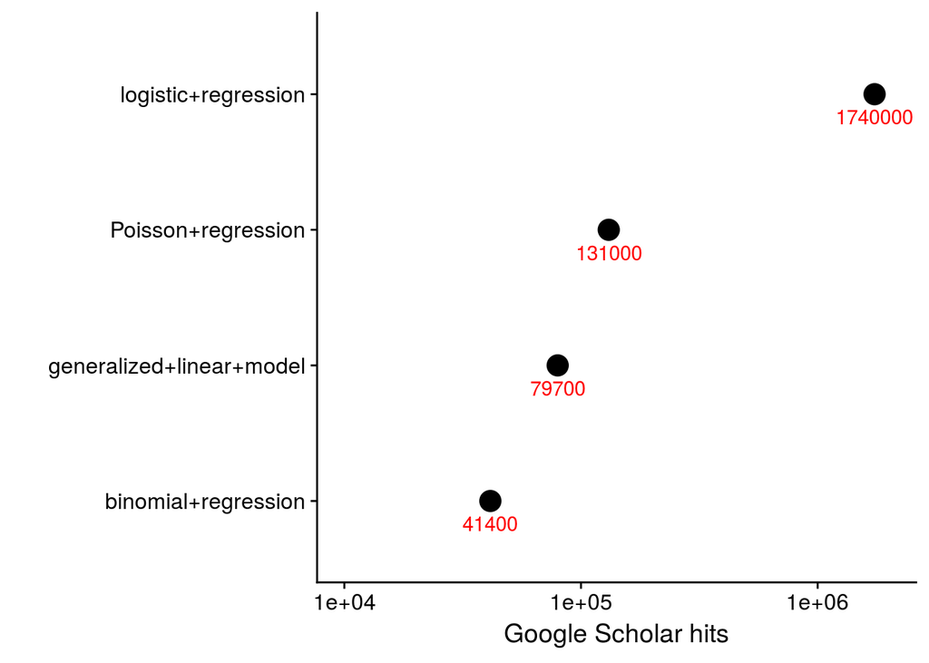

## Family

- family: what kind of data do I have?
  - from **first principles**: family specifies the relationship between the mean and variance
  - binomial: proportions, out of a total number of counts; includes binary (Bernoulli) (“logistic regression”)
  - Poisson (independent counts, no set maximum, or far from the maximum)
  - other (Normal (`"gaussian"`), Gamma)
- default family for `glm` is Gaussian

## link functions

- transform *prediction*, not response
- e.g. rather than $\log(\mu) = \beta_0+\beta_1 x$, use $\mu = \exp(\beta_0+\beta_1 x)$
- in this case log is the **link function**, exp is the **inverse link** function
- extreme observations don’t cause problems (usually)

## family definitions

- link function plus variance function
- typical defaults
  - Poisson: log (exponential)
  - binomial: logit/log-odds (logistic)

## log link

- proportional scaling of effects
- small values of coefficients ($<0.1$) $\approx$ proportionality
- otherwise change per unit is $\exp(\beta)$
- large parameter values ($>10$) mean some kind of trouble

## logit link/logistic function

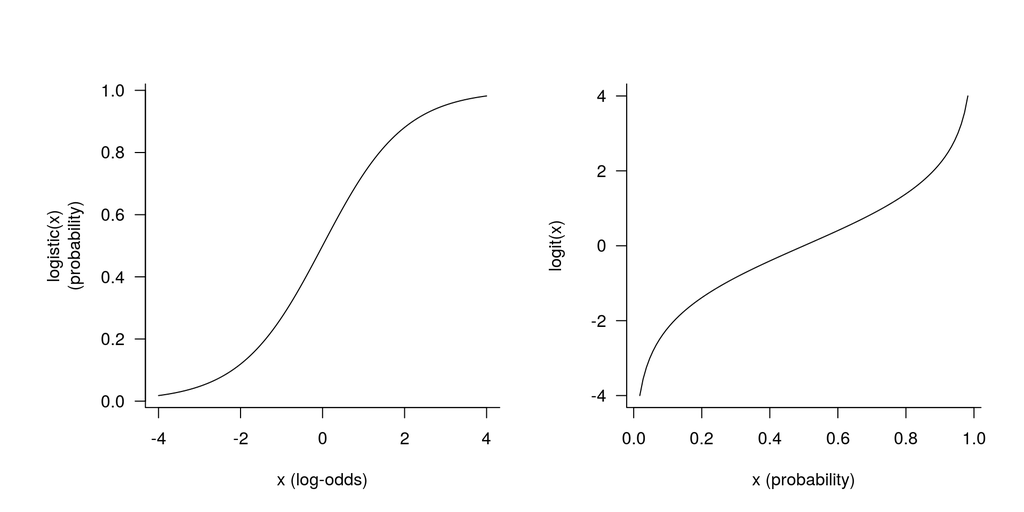

- `qlogis()` function (`plogis()` is logistic/inverse-link)
- *log-odds* ($\log(p/(1-p))$)
- most natural scale for probability calculations
- interpretation depends on *base probability*
  - small probability: like log (proportional)
  - large probability: like log(1-p)
  - intermediate ($0.3 <p <0.7$): effect $\approx \beta/4$

## binomial models

- for Poisson, Bernoulli responses we only need one piece of information
- how do we specify denominator ($N$ in $k/N$)?
- traditional R: response is two-column matrix `cbind(k,N-k)` **not** `cbind(k,N)`
- also allowed: response is proportion ($k/N$), also specify `weights=N`
- if equal for all cases and specified on the fly need to replicate:  
  `glm(p~...,data,weights=rep(N,nrow(data)))`

## diagnostics

- a little harder than linear models: `plot` is still somewhat useful
- binary data especially hard (e.g. `arm::binnedplot`)
- goodness of fit tests, $R^2$ etc. hard (can always compute `cor(observed,predict(model, type="response"))`)
- residuals are *Pearson residuals* by default ($(\textrm{obs}-\textrm{exp})/V(\textrm{exp})$); predicted values are on the effect scale (e.g. log/logit) by default (use `type="response"` to get data-scale predictions)
- also see `DHARMa` package

## overdispersion

- too much variance
- more detail later
- should have residual df $\approx$ residual deviance

## back-transformation

- confidence intervals are symmetric on link scale
- can back-transform estimates and CIs for log
- logit is hard (must pick a reference level)
- don’t back-transform standard errors!

## estimation

- iteratively re-weighted least-squares
- usually Just Works

## inference

like LMs, but:

- one-parameter tests are usually $Z$ rather than $t$
- CIs based on standard errors are approximate (Wald)
- `confint.glm()` computes *likelihood profile* CIs

## Common(est?) `glm()` problems

# Example

## AIDS (Australia: Dobson & Barnett)

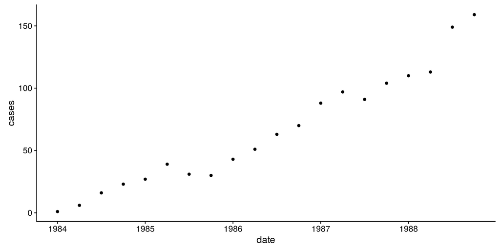

```r
aids <- read.csv("../data/aids.csv")
aids <- transform(aids, date=year+(quarter-1)/4)
print(gg0 <- ggplot(aids,aes(date,cases))+geom_point())
```

## Easy GLMs with ggplot

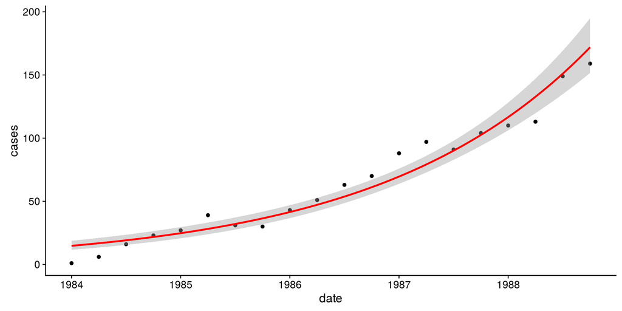

```r
print(gg1 <- gg0 + geom_smooth(method="glm",colour="red",
          method.args=list(family="quasipoisson")))
```

## Equivalent code

```r
g1 <- glm(cases~date,aids,family=quasipoisson(link="log"))
summary(g1)
```

```
##
## Call:
## glm(formula = cases ~ date, family = quasipoisson(link = "log"),
##     data = aids)
##
## Deviance Residuals:
##     Min       1Q   Median       3Q      Max
## -4.7046  -0.7978   0.1218   0.6849   2.1217
##
## Coefficients:
##               Estimate Std. Error t value Pr(>|t|)
## (Intercept) -1.023e+03  6.806e+01  -15.03 1.25e-11 ***
## date         5.168e-01  3.425e-02   15.09 1.16e-11 ***
## ---
## Signif. codes:  0 '***' 0.001 '**' 0.01 '*' 0.05 '.' 0.1 ' ' 1
##
## (Dispersion parameter for quasipoisson family taken to be 2.354647)
##
##     Null deviance: 677.26  on 19  degrees of freedom
## Residual deviance:  53.02  on 18  degrees of freedom
## AIC: NA
##
## Number of Fisher Scoring iterations: 4
```

## Diagnostics (`plot(g1)`)

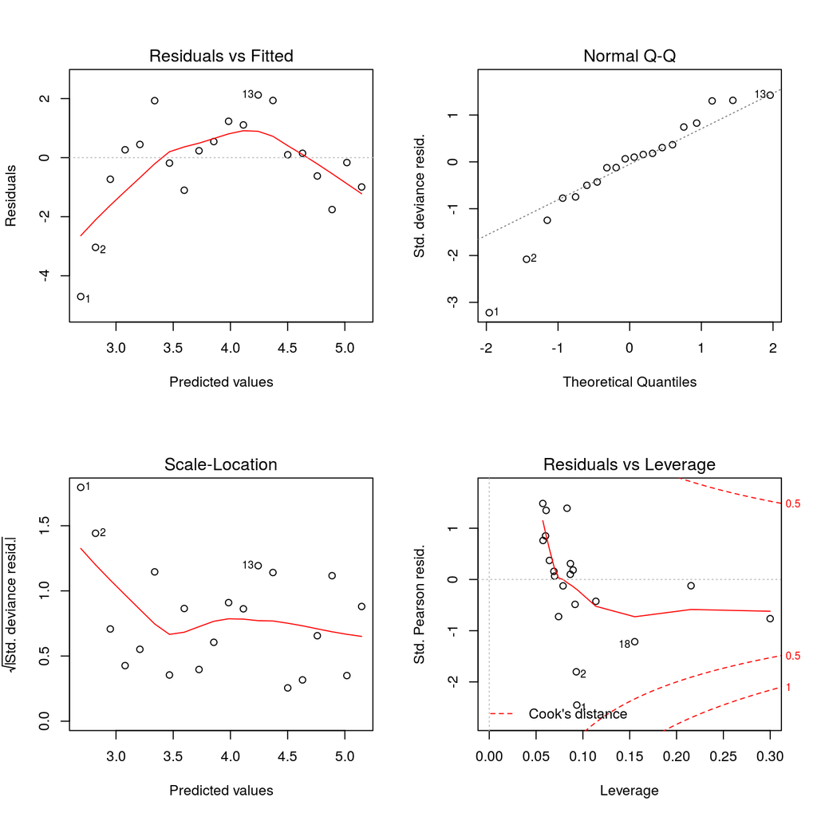

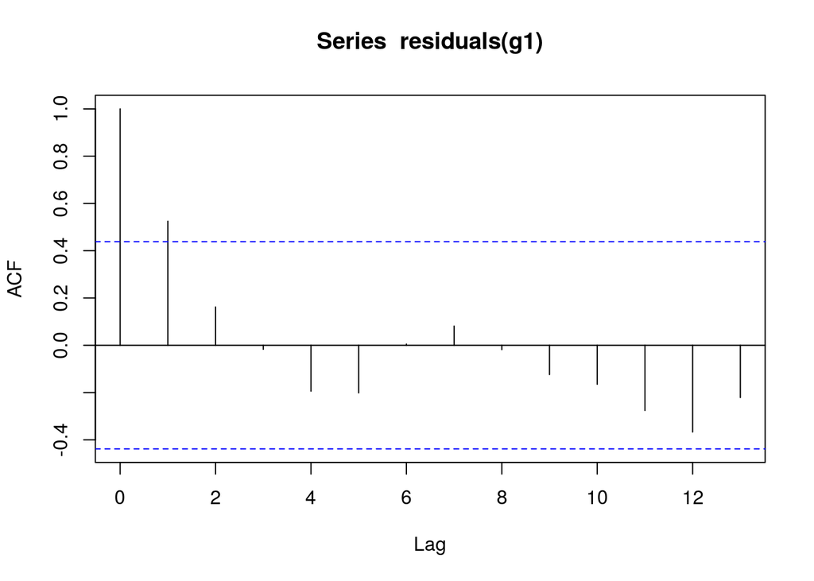

```r
acf(residuals(g1)) ## check autocorrelation
```

## ggplot: check out quadratic model

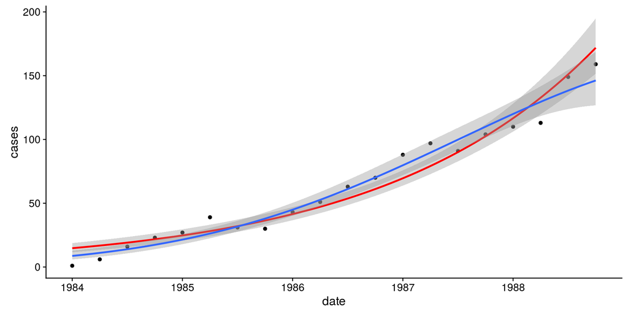

```r
print(gg2 <- gg1+geom_smooth(method="glm",formula=y~poly(x,2),
            method.args=list(family="quasipoisson")))
```

## on log scale

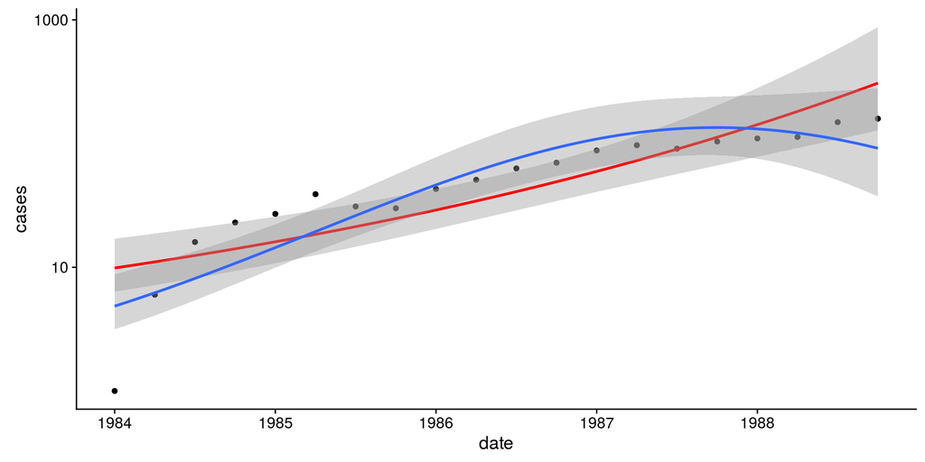

```r
print(gg2+scale_y_log10())
```

## improved model

```r
g2 <- update(g1,.~poly(date,2))
summary(g2)
```

```
##
## Call:
## glm(formula = cases ~ poly(date, 2), family = quasipoisson(link = "log"),
##     data = aids)
##
## Deviance Residuals:
##     Min       1Q   Median       3Q      Max
## -3.3290  -0.9071  -0.0761   0.8985   2.3209
##
## Coefficients:
##                Estimate Std. Error t value Pr(>|t|)
## (Intercept)     3.86859    0.05004  77.311  < 2e-16 ***
## poly(date, 2)1  3.82934    0.25162  15.219 2.46e-11 ***
## poly(date, 2)2 -0.68335    0.19716  -3.466  0.00295 **
## ---
## Signif. codes:  0 '***' 0.001 '**' 0.01 '*' 0.05 '.' 0.1 ' ' 1
##
## (Dispersion parameter for quasipoisson family taken to be 1.657309)
##
##     Null deviance: 677.264  on 19  degrees of freedom
## Residual deviance:  31.992  on 17  degrees of freedom
## AIC: NA
##
## Number of Fisher Scoring iterations: 4
```

```r
anova(g1,g2,test="F") ## for quasi-models specifically
```

```
## Analysis of Deviance Table
##
## Model 1: cases ~ date
## Model 2: cases ~ poly(date, 2)
##   Resid. Df Resid. Dev Df Deviance      F   Pr(>F)
## 1        18     53.020
## 2        17     31.992  1   21.028 12.688 0.002399 **
## ---
## Signif. codes:  0 '***' 0.001 '**' 0.01 '*' 0.05 '.' 0.1 ' ' 1
```

## new diagnostics

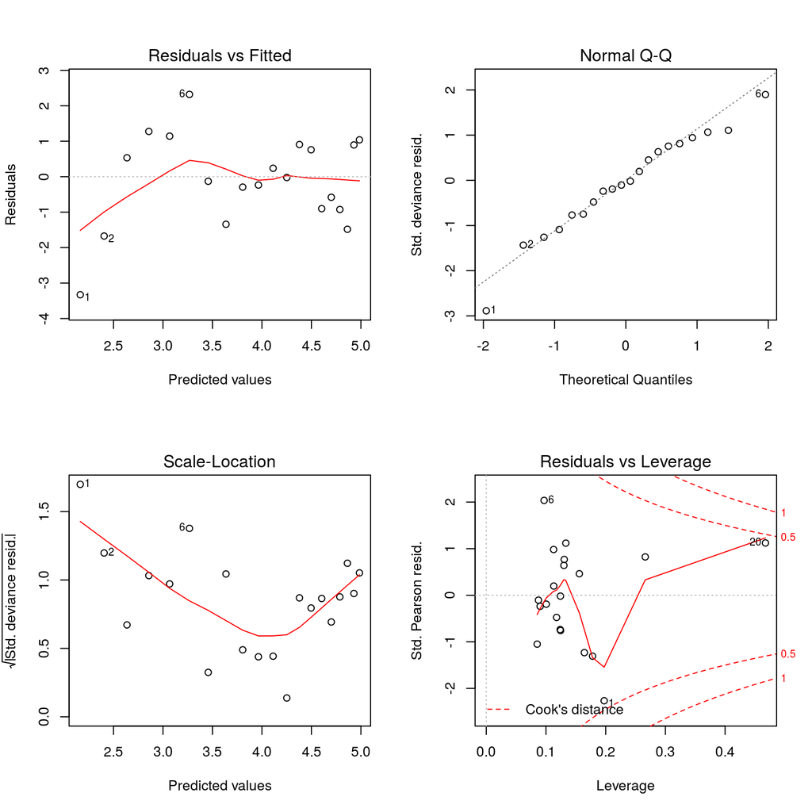

## autocorrelation function

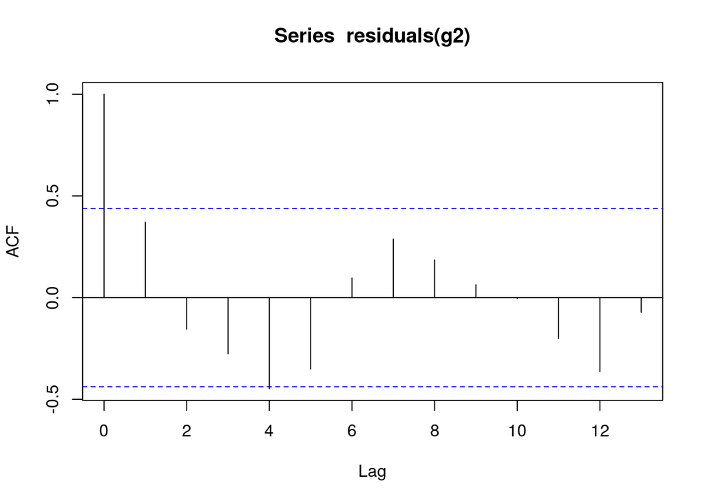

```r
acf(residuals(g2)) ## check autocorrelation
```

## References

Gotelli, Nicholas J., and Aaron M. Ellison. 2004. *A Primer of Ecological Statistics*. Sunderland, MA: Sinauer.

Schielzeth, Holger. 2010. “Simple Means to Improve the Interpretability of Regression Coefficients.” *Methods in Ecology and Evolution* 1: 103–13. doi:10.1111/j.2041-210X.2010.00012.x.

Tiwari, Manjula, Karen A. Bjorndal, Alan B. Bolten, and Benjamin M. Bolker. 2006. “Evaluation of Density-Dependent Processes and Green Turtle *Chelonia Mydas* Hatchling Production at Tortuguero, Costa Rica.” *Marine Ecology Progress Series* 326: 283–93.

Wilkinson, G. N., and C. E. Rogers. 1973. “Symbolic Description of Factorial Models for Analysis of Variance.” *Applied Statistics* 22 (3): 392–99. doi:10.2307/2346786.